# R Notebook

```r
library(tidyverse)
library(modelr)
library(broom)
```

Load the data into a dataframe project

```r
project_management <- read_csv("data/project_management.csv") %>% janitor::clean_names()
```

Plot the data, taking estimated_length as the independent variable and actual_length as the dependent variable.

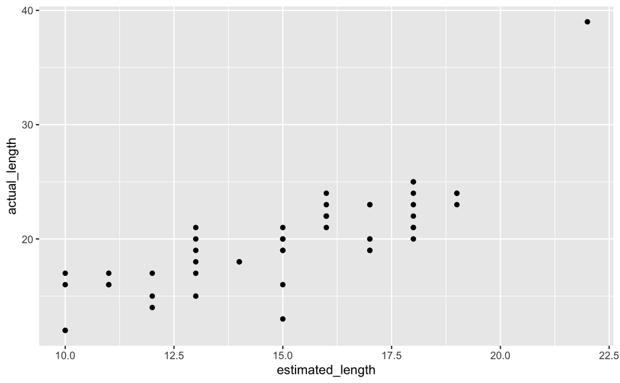

```r
project_management %>%
  ggplot(aes(x = estimated_length,
             y = actual_length))+
  geom_point()
```

Calculate the correlation coefficient of estimated_length and actual_length and interpret the value you obtain.

```r
project_management %>%
  summarise(correlation = cor(estimated_length, actual_length))
```

| correlation |
| --- |
| 0.8046597 |

This falls within the ranges of 0.80 - 0.99 which suggests a very strong correlation

Perform a simple linear regression using actual_length as the dependent variable, and estimated_length as the independent variable. Save the model object to a variable.

```r
model
```

```
Call:
lm(formula = actual_length ~ estimated_length, data = project_management)

Coefficients:
     (Intercept)  estimated_length
           1.416             1.223
```

Interpret the regression coefficient of estimated_length (i.e. slope, gradient) you obtain from the model. How do you interpret the r2 value reported by the model?

```r
glance_output <- model %>%
  glance() %>%
  janitor::clean_names()

glance_output
```

| r_squared | adj_r_squared | sigma | statistic | p_value | df | log_lik | aic | bic | deviance | df_residual | nobs |
| --- | --- | --- | --- | --- | --- | --- | --- | --- | --- | --- | --- |
| 0.6474772 | 0.640133 | 2.606163 | 88.16142 | 1.911284e-12 | 1 | -117.8203 | 241.6407 | 247.3767 | 326.0201 | 48 | 50 |

The r^2 value of 0.65 means that the model is an OK fit and therefore, the actual days for a job can only be estimated to an OK degree of certainty

Is the relationship statistically significant? Remember, to assess this you need to check the p-value of the regression coefficient (or slope/gradient). But you should first check the regression diagnostic plots to see if the p-value will be reliable (don’t worry about any outlier points you see in the diagnostic plots, we’ll return to them in the extension).

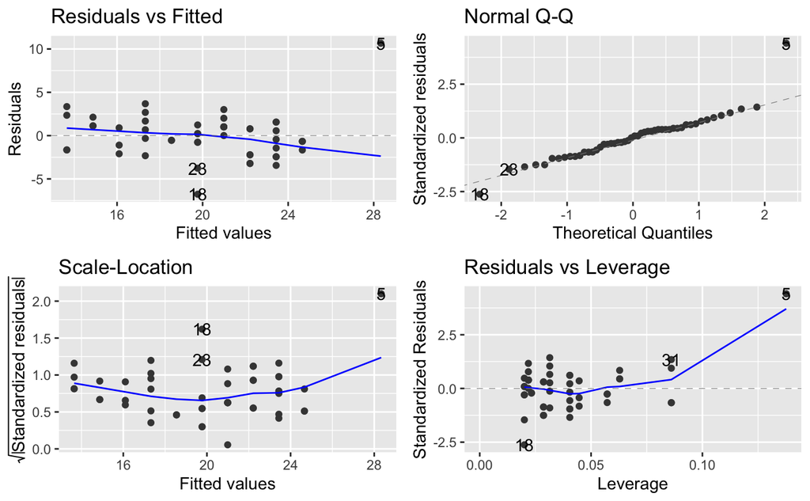

```r
library(ggfortify)

autoplot(model)
```

From the diagnostic plots we can see:

Residuals vs Fitted: The residuals tend to descrease as the fitted values increase, which shouuldn’t be the case and suggests that any p-value could be misleading

Scale-Location: Again, there seems to be a pattern to the smoothed line which is undesirable and agains suggests that the p-value cannot be accurate

```r
glance_output
```

| r_squared | adj_r_squared | sigma | statistic | p_value | df | log_lik | aic | bic | deviance | df_residual | nobs |
| --- | --- | --- | --- | --- | --- | --- | --- | --- | --- | --- | --- |
| 0.6474772 | 0.640133 | 2.606163 | 88.16142 | 1.911284e-12 | 1 | -117.8203 | 241.6407 | 247.3767 | 326.0201 | 48 | 50 |

The p-value is tending towards 0 which is suggesting that there is a statistically significant relationship between the actual days and estimated days of a job

```r
summary(model)
```

```
Call:
lm(formula = actual_length ~ estimated_length, data = project_management)

Residuals:
    Min      1Q  Median      3Q     Max
-6.7687 -1.6513  0.1195  1.1252 10.6669

Coefficients:
                 Estimate Std. Error t value Pr(>|t|)
(Intercept)        1.4164     2.0069   0.706    0.484
estimated_length   1.2235     0.1303   9.389 1.91e-12 ***
---
Signif. codes:  0 ‘***’ 0.001 ‘**’ 0.01 ‘*’ 0.05 ‘.’ 0.1 ‘ ’ 1

Residual standard error: 2.606 on 48 degrees of freedom
Multiple R-squared:  0.6475,    Adjusted R-squared:  0.6401
F-statistic: 88.16 on 1 and 48 DF,  p-value: 1.911e-12
```

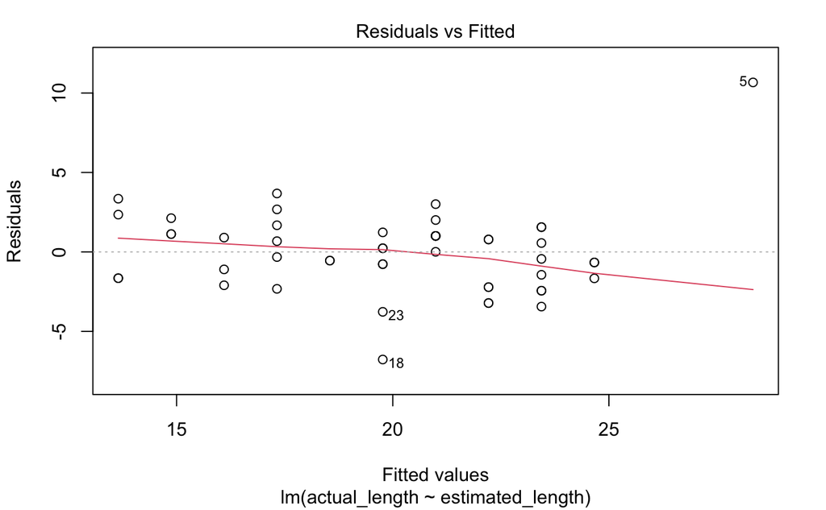

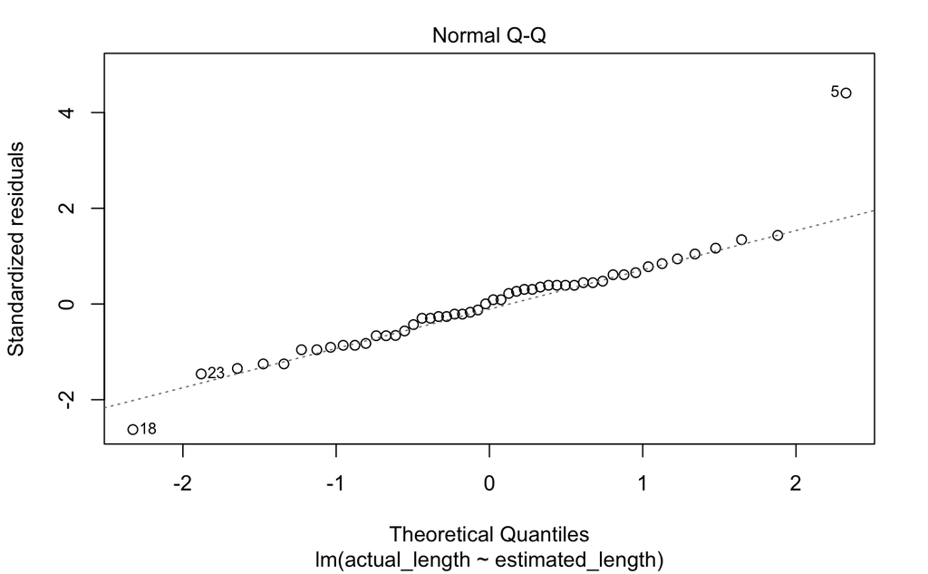

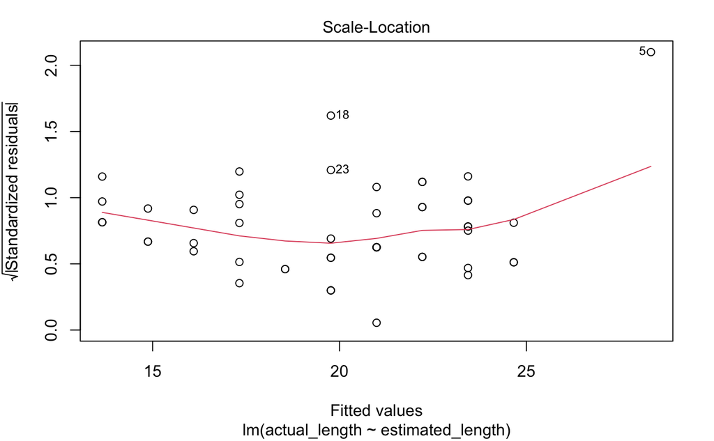

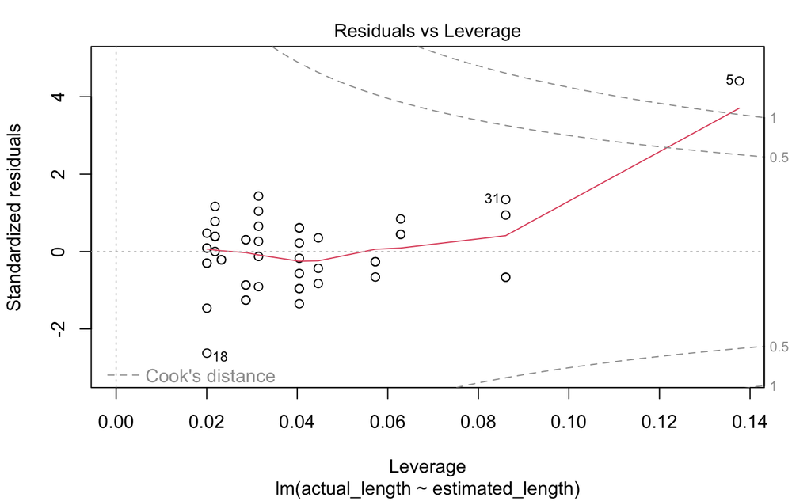

```r
plot(model) +
  geom_text(aes(label = 1:nrow(project_management)))
```